# Linear mixed-effects models

STAT 230

April 20, 2017

This is a brief introduction to a pretty big subject. To find more you can do Google searches like

- “mixed effects models” r (nlme OR lme4)

E.g. you can find anything from a nice gentle tutorial here:

- https://arxiv.org/ftp/arxiv/papers/1308/1308.5499.pdf

to the full story in the book “Mixed-Effects Models in S and S-PLUS” by Pinheiro and Bates.

# Male and female blood pressures

## Simulating a data set

```r
set.seed(230)
nm <- nf <- 10
n <- nm+nf
timesm <- sample(1:10, nm, replace=TRUE)
timesf <- sample(1:10, nf, replace=TRUE)
times <- c(timesm, timesf)
id <- rep(1:n, times=times)
idfac <- as.factor(id)
N <- length(id)
male <- rep(c(1,0), times=c(sum(timesm), sum(timesf)))
beta0 <- c(125, 0)
# muf=beta0[1]; mum=beta0[1]+beta0[2]
sigb0 <- 12
b <- rnorm(n, 0, sigb0)
bb <- b[id]
sige0 <- 10
e <- rnorm(N, 0, sige0)
bp0 <- beta0[1] + beta0[2]*male + bb
bp <- bp0 + e
```

Data with the truth (we would not see the bp0 column):

```r
dat0 <- data.frame(id, idfac, male, bp0, bp)
```

Data as we would see it:

```r
dat <- data.frame(id, idfac, male, bp)
```

Here’s a plot of the data:

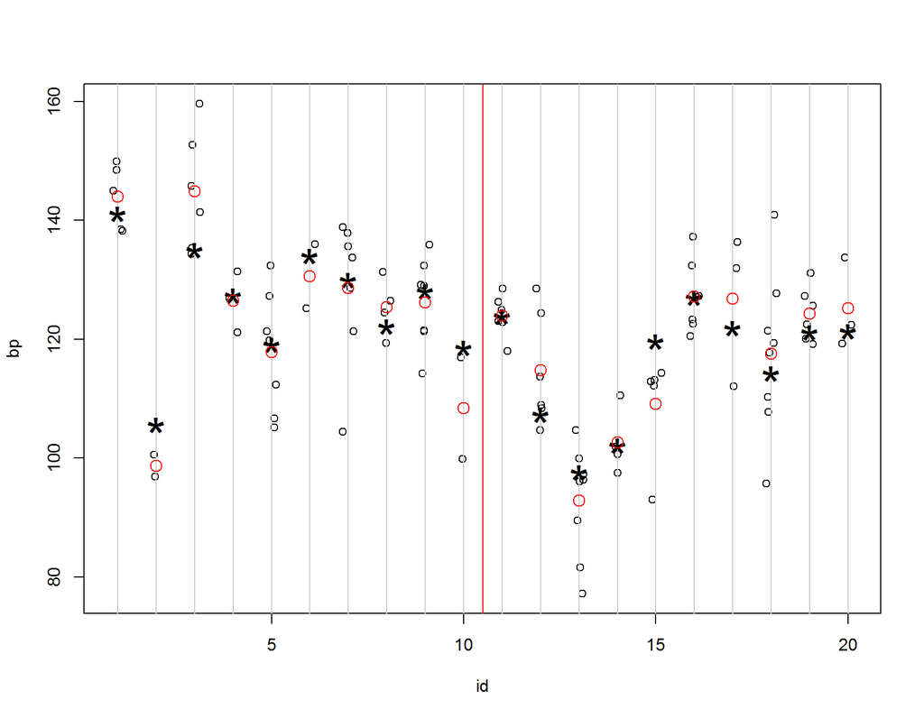

```r
jit <- .15
plot(id + runif(N,-jit,jit), bp, xlab='id')
for(j in 1:n){
  abline(v=j, col=gray(.8))
}
# Show each "true" bp0's with a "*":
points(1:n, unique(bp0), pch="*", cex=3)
abline(v=nm+0.5, col='red')
# Next we'll add red points showing the sample mean for each person:
library(dplyr)
dat <- group_by(dat, id)
sample.means <- as.vector(summarize(dat, means=mean(bp))[,2])
points(1:n, sample.means$means, col=2, cex=1.5)
```

I’ll make the above into a function so we can make the same plot later:

```r
start_plot <- function(){
  jit <- .15
  plot(id + runif(N,-jit,jit), bp, xlab='id')
  for(j in 1:n){abline(v=j, col=gray(.8))}
  # Show each "true" bp0's with a "*":
  points(1:n, unique(bp0), pch="*", cex=3)
  abline(v=nm+0.5, col='red')
  # Next we'll add red points showing the sample mean for each person:
  sample.means <- as.vector(summarize(dat, means=mean(bp))[,2])
  points(1:n, sample.means$means, col=2, cex=1.5)
}
```

## Some inappropriate analyses

```r
summary(lm(bp ~ male, dat))
```

```
##
## Call:
## lm(formula = bp ~ male, data = dat)
##
## Residuals:
##     Min      1Q  Median      3Q     Max
## -38.217  -7.668   2.540  10.028  31.772
##
## Coefficients:
##             Estimate Std. Error t value Pr(>|t|)
## (Intercept)  115.435      1.910  60.426  < 2e-16 ***
## male          12.458      2.862   4.353 3.28e-05 ***
## ---
## Signif. codes:  0 '***' 0.001 '**' 0.01 '*' 0.05 '.' 0.1 ' ' 1
##
## Residual standard error: 14.3 on 99 degrees of freedom
## Multiple R-squared:  0.1606, Adjusted R-squared:  0.1522
## F-statistic: 18.95 on 1 and 99 DF,  p-value: 3.277e-05
```

This is bad, because we got a very small P value indicating a convincing rejection of the null hypothesis, whereas we know by the way we simulated this data set that the null hypothesis is true! The problem is that we have ignored the grouping of the bp values due to multiple measurements coming from each person. That is, in this inappropriate analysis we have acted as if our data contains an independent bp measurement from each of 56 females and 45 males (a total of 56 measurements came from the 10 females and 45 measurements came from the 10 males). We do not have samples of size 56 and 45, but rather we have varying amounts of information about just 10 males and 10 females.

```r
summary(lm(bp ~ male + id, dat))
```

```
##
## Call:
## lm(formula = bp ~ male + id, data = dat)
##
## Residuals:
##     Min      1Q  Median      3Q     Max
## -37.705  -7.930   2.776   9.716  32.353
##
## Coefficients:
##             Estimate Std. Error t value Pr(>|t|)
## (Intercept) 111.9686     8.0516  13.906   <2e-16 ***
## male         14.6611     5.7419   2.553   0.0122 *
## id            0.2273     0.5128   0.443   0.6586
## ---
## Signif. codes:  0 '***' 0.001 '**' 0.01 '*' 0.05 '.' 0.1 ' ' 1
##
## Residual standard error: 14.35 on 98 degrees of freedom
## Multiple R-squared:  0.1623, Adjusted R-squared:  0.1452
## F-statistic: 9.495 on 2 and 98 DF,  p-value: 0.0001702
```

This last one is just a silly idea, since it treats id as a numeric variable, which makes no sense. Next we’ll try including id as a factor in the regression:

```r
summary(lm(bp ~ male + idfac, dat))
```

```
##
## Call:
## lm(formula = bp ~ male + idfac, data = dat)
##
## Residuals:
##      Min       1Q   Median       3Q      Max
## -24.2219  -5.3877   0.9168   5.1764  23.3446
##
## Coefficients: (1 not defined because of singularities)
##             Estimate Std. Error t value Pr(>|t|)
## (Intercept) 125.1720     5.1492  24.309  < 2e-16 ***
## male         18.8632     6.5133   2.896  0.00486 **
## idfac2      -45.3227     7.4620  -6.074 3.86e-08 ***
## idfac3        0.8421     5.4006   0.156  0.87648
## idfac4      -17.5548     6.5133  -2.695  0.00855 **
## idfac5      -26.1750     5.2223  -5.012 3.11e-06 ***
## idfac6      -13.4158     7.4620  -1.798  0.07592 .
## idfac7      -15.3726     5.2223  -2.944  0.00423 **
## idfac8      -18.6098     5.9829  -3.111  0.00258 **
## idfac9      -17.8267     5.2223  -3.414  0.00100 **
## idfac10     -35.6365     7.4620  -4.776 7.85e-06 ***
## idfac11      -1.2324     6.3065  -0.195  0.84556
## idfac12     -10.3671     6.3065  -1.644  0.10408
## idfac13     -32.3329     6.0380  -5.355 7.82e-07 ***
## idfac14     -22.4945     6.8118  -3.302  0.00143 **
## idfac15     -16.0504     6.5133  -2.464  0.01585 *
## idfac16       2.0224     6.1545   0.329  0.74331
## idfac17       1.6294     7.2821   0.224  0.82351
## idfac18      -7.5637     6.0380  -1.253  0.21392
## idfac19      -0.8871     6.3065  -0.141  0.88849
## idfac20           NA         NA      NA       NA
## ---
## Signif. codes:  0 '***' 0.001 '**' 0.01 '*' 0.05 '.' 0.1 ' ' 1
##
## Residual standard error: 8.919 on 81 degrees of freedom
## Multiple R-squared:  0.7327, Adjusted R-squared:   0.67
## F-statistic: 11.69 on 19 and 81 DF,  p-value: 4.668e-16
```

Here we got a small P value for male again, which is not good, and lots of individual coefficients, one of which is a strange NA. And here just for fun is the same regression with the explanatory variables written in the other order:

```r
summary(lm(bp ~ idfac + male, dat))
```

```
##
## Call:
## lm(formula = bp ~ idfac + male, data = dat)
##
## Residuals:
##      Min       1Q   Median       3Q      Max
## -24.2219  -5.3877   0.9168   5.1764  23.3446
##
## Coefficients: (1 not defined because of singularities)
##             Estimate Std. Error t value Pr(>|t|)
## (Intercept) 144.0352     3.9886  36.112  < 2e-16 ***
## idfac2      -45.3227     7.4620  -6.074 3.86e-08 ***
## idfac3        0.8421     5.4006   0.156 0.876478
## idfac4      -17.5548     6.5133  -2.695 0.008551 **
## idfac5      -26.1750     5.2223  -5.012 3.11e-06 ***
## idfac6      -13.4158     7.4620  -1.798 0.075920 .
## idfac7      -15.3726     5.2223  -2.944 0.004231 **
## idfac8      -18.6098     5.9829  -3.111 0.002579 **
## idfac9      -17.8267     5.2223  -3.414 0.001004 **
## idfac10     -35.6365     7.4620  -4.776 7.85e-06 ***
## idfac11     -20.0956     5.4006  -3.721 0.000365 ***
## idfac12     -29.2304     5.4006  -5.412 6.18e-07 ***
## idfac13     -51.1961     5.0845 -10.069 6.21e-16 ***
## idfac14     -41.3577     5.9829  -6.913 9.94e-10 ***
## idfac15     -34.9136     5.6407  -6.190 2.35e-08 ***
## idfac16     -16.8408     5.2223  -3.225 0.001818 **
## idfac17     -17.2338     6.5133  -2.646 0.009784 **
## idfac18     -26.4269     5.0845  -5.198 1.48e-06 ***
## idfac19     -19.7503     5.4006  -3.657 0.000452 ***
## idfac20     -18.8632     6.5133  -2.896 0.004856 **
## male              NA         NA      NA       NA
## ---
## Signif. codes:  0 '***' 0.001 '**' 0.01 '*' 0.05 '.' 0.1 ' ' 1
##
## Residual standard error: 8.919 on 81 degrees of freedom
## Multiple R-squared:  0.7327, Adjusted R-squared:   0.67
## F-statistic: 11.69 on 19 and 81 DF,  p-value: 4.668e-16
```

Hmm, here we don’t get a result for the variable of interest (`male`) at all!

OK, so that was some examples of how not to do it. How could we do a more appropriate analysis?

## Mixed effects models

Two R packages that do this are nlme, lme4. We’ll use the first one, nlme.

We use a model that has `male` as a “fixed effect” and include a `random effect` that adds a random amount to each person’s true blood pressure. To interpret why it is written as `~1|id`, you can think that “we are adding a random multiple of 1 for each id”.

```r
library(nlme)
m1 <- lme(bp ~ male, random = ~1|id, data=dat)
sm1 <- summary(m1)
sm1
```

```
## Linear mixed-effects model fit by REML
##  Data: dat
##       AIC      BIC    logLik
##   770.545 780.9255 -381.2725
##
## Random effects:
##  Formula: ~1 | id
##         (Intercept) Residual
## StdDev:    12.01619 8.933947
##
## Fixed effects: bp ~ male
##                Value Std.Error DF   t-value p-value
## (Intercept) 116.3266  4.002656 81 29.062361  0.0000
## male          9.3265  5.716230 18  1.631582  0.1201
##  Correlation:
##      (Intr)
## male -0.7
##
## Standardized Within-Group Residuals:
##         Min          Q1         Med          Q3         Max
## -2.68657220 -0.54477231  0.09528244  0.62240418  2.62229228
##
## Number of Observations: 101
## Number of Groups: 20
```

```r
names(sm1)
```

```
##  [1] "modelStruct"  "dims"         "contrasts"    "coefficients"
##  [5] "varFix"       "sigma"        "apVar"        "logLik"
##  [9] "numIter"      "groups"       "call"         "terms"
## [13] "method"       "fitted"       "residuals"    "fixDF"
## [17] "na.action"    "data"         "corFixed"     "tTable"
## [21] "BIC"          "AIC"
```

```r
pval <- sm1$tTable[2,5]
pval
```

```
## [1] 0.1201394
```

The model has estimated the male population average bp to be 9.3 higher than the female average bp, but the standard error is large enough that this difference is not statistically significant, with a P value of 0.12 (not small). That is, we are not confident that the male population average bp is higher than the female population average bp; it could easily be equal or lower.

## Looking further at what we got

```r
# BLUPs (fitted values from lme model)
s1 <- summary(m1)
names(s1)
```

```
##  [1] "modelStruct"  "dims"         "contrasts"    "coefficients"
##  [5] "varFix"       "sigma"        "apVar"        "logLik"
##  [9] "numIter"      "groups"       "call"         "terms"
## [13] "method"       "fitted"       "residuals"    "fixDF"
## [17] "na.action"    "data"         "corFixed"     "tTable"
## [21] "BIC"          "AIC"
```

```r
m1$fitted
```

```
##        fixed        id
## 1   125.6531 142.20523
## 2   125.6531 142.20523
## 3   125.6531 142.20523
## 4   125.6531 142.20523
## 5   125.6531 142.20523
## 6   125.6531 104.54619
## 7   125.6531 104.54619
## 8   125.6531 143.25555
## 9   125.6531 143.25555
## 10  125.6531 143.25555
## 11  125.6531 143.25555
## 12  125.6531 143.25555
## 13  125.6531 143.25555
## 14  125.6531 126.35166
```

[output cut: 87 more lines]

```r
# The first column above is the estimated fixed effect for each person, that is, the estimated population average bp for that person's sex. The second column is the sum of the fixed and random effect for each person, that is, the estimate for the person's "true blood pressure", bp0. Here is the second column as a vector:
m1$fitted[,'id']
```

```
##         1         2         3         4         5         6         7
## 142.20523 142.20523 142.20523 142.20523 142.20523 104.54619 104.54619
##         8         9        10        11        12        13        14
## 143.25555 143.25555 143.25555 143.25555 143.25555 143.25555 126.35166
##        15        16        17        18        19        20        21
## 126.35166 126.35166 118.43050 118.43050 118.43050 118.43050 118.43050
##        22        23        24        25        26        27        28
## 118.43050 118.43050 129.54398 129.54398 128.44226 128.44226 128.44226
##        29        30        31        32        33        34        35
## 128.44226 128.44226 128.44226 128.44226 125.45303 125.45303 125.45303
##        36        37        38        39        40        41        42
## 125.45303 126.16784 126.16784 126.16784 126.16784 126.16784 126.16784
##        43        44        45        46        47        48        49
## 126.16784 112.13498 112.13498 123.29734 123.29734 123.29734 123.29734
##        50        51        52        53        54        55        56
## 123.29734 123.29734 114.93318 114.93318 114.93318 114.93318 114.93318
##        57        58        59        60        61        62        63
## 114.93318  94.35712  94.35712  94.35712  94.35712  94.35712  94.35712
##        64        65        66        67        68        69        70
##  94.35712  94.35712 104.33467 104.33467 104.33467 104.33467 109.83881
##        71        72        73        74        75        76        77
## 109.83881 109.83881 109.83881 109.83881 126.39893 126.39893 126.39893
##        78        79        80        81        82        83        84
## 126.39893 126.39893 126.39893 126.39893 125.17158 125.17158 125.17158
##        85        86        87        88        89        90        91
## 117.52539 117.52539 117.52539 117.52539 117.52539 117.52539 117.52539
##        92        93        94        95        96        97        98
## 117.52539 123.61354 123.61354 123.61354 123.61354 123.61354 123.61354
##        99       100       101
## 123.79570 123.79570 123.79570
```

```r
# Here are the fitted fixed effects
m1$coef$fixed  # or:
```

```
## (Intercept)        male
##  116.326627    9.326496
```

```r
fixef(m1)
```

```
## (Intercept)        male
##  116.326627    9.326496
```

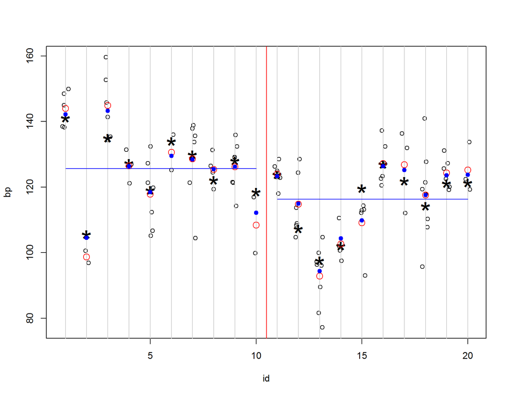

```r
# Next we'll put show our plot from before, adding blue points showing the estimated true blood pressures and lines showing the fixed effects for each sex:
start_plot()
points(id, m1$fitted[,'id'], pch=19, col='blue')
lines(c(1,nm),rep(sum(fixef(m1)),2), col='blue')
lines(c(nm+1,n),rep(fixef(m1)[1],2), col='blue')
```

```r
# We can see that the predicted random effects (blue estimated true blood pressures) are moved (or "shrunken") away from the average for each person (red circles) toward the estimated group means (horizontal blue lines). The fraction of shrinkage is larger for people having smaller number of measurements.

# The 20 "BLUP"s (best linear unbiased predictors) of the true blood pressures:
pred = unique(m1$fitted[,'id'])
# or:
pred = fixef(m1)[1] +
  fixef(m1)[2] * rep(c(1,0),c(nm,nf)) +
  ranef(m1)[[1]]
# The 20 actual true blood pressures (known only because we did a simulation, and not used in the mixed linear model we fit):
bps.true = beta0[1] + (beta0[2] * ((1:n)<=nm)) + b
```

How do the BLUPs do compared to the sample means?

```r
mean((sample.means-bps.true)^2)
```

```
## [1] 26.8319
```

```r
mean((pred-bps.true)^2)
```

```
## [1] 17.70084
```

## Was that a fluke?

Here we’ll do a larger simulation: repeat the above, say 200 times, and record relevant results from each iteration.

```r
set.seed(230)
nit <- 200
results <- matrix(NA, nit, 4)
colnames(results) <- c("pvalbad", "pval", "sample_means_MSE", "lme_preds_MSE")
for(it in 1:nit){
  nm <- nf <- 10
  n <- nm+nf
  timesm <- sample(1:10, nm, replace=TRUE)
  timesf <- sample(1:10, nf, replace=TRUE)
  times <- c(timesm, timesf)
  id <- rep(1:n, times=times)
  idfac <- as.factor(id)
  N <- length(id)
  male <- rep(c(1,0), times=c(sum(timesm), sum(timesf)))
  beta0 <- c(125, 0)
  sigb0 <- 12
  b <- rnorm(n, 0, sigb0)
  bb <- b[id]
  sige0 <- 10
  e <- rnorm(N, 0, sige0)
  bp0 <- beta0[1] + beta0[2]*male + bb
  bp <- bp0 + e
  dat <- data.frame(id, idfac, male, bp)
  dat <- group_by(dat, id)
  sample.means <- summarize(dat, mean=mean(bp))$mean
  mbad <- lm(bp ~ male)
  smbad <- summary(mbad)
  pvalbad <- smbad$coefficients["male",4]
  m1 <- lme(bp ~ male, random=~1|id, data=dat)
  sm1 <- summary(m1)
  pval <- sm1$tTable["male", "p-value"]
  # the 20 BLUPs:
  pred = fixef(m1)[1] +
    fixef(m1)[2] * rep(c(1,0),c(nm,nf)) +
    ranef(m1)[[1]]
  bps.true = beta0[1] + beta0[2] * ((1:n)<=nm) + b
  MSE_sample_means <- mean((sample.means-bps.true)^2)
  MSE_lme_preds <- mean((pred-bps.true)^2)
  results[it,] <- c(pvalbad, pval, MSE_sample_means, MSE_lme_preds)
}
```

Look at how we did:

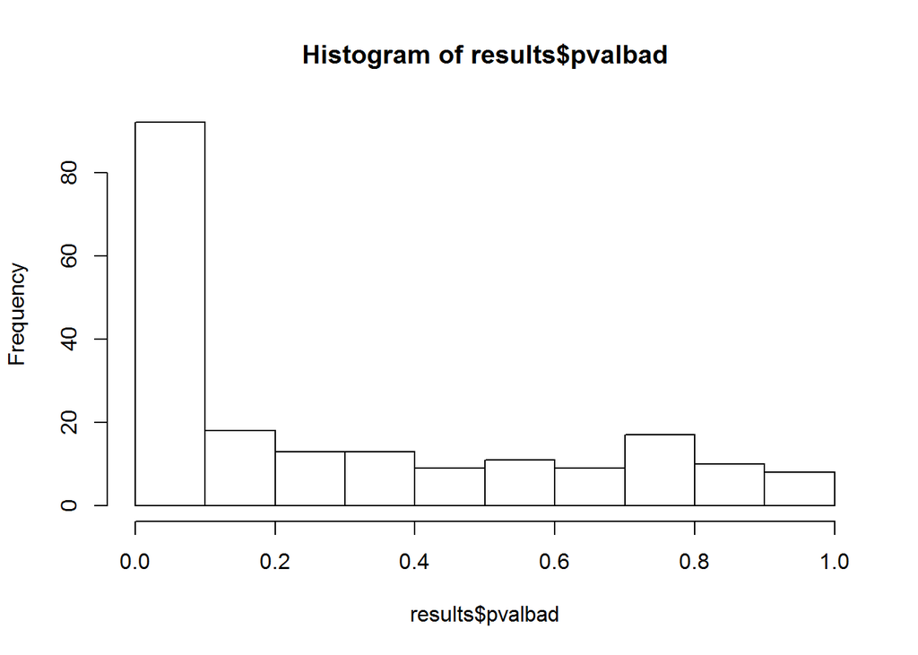

```r
results <- data.frame(results)
hist(results$pvalbad)
```

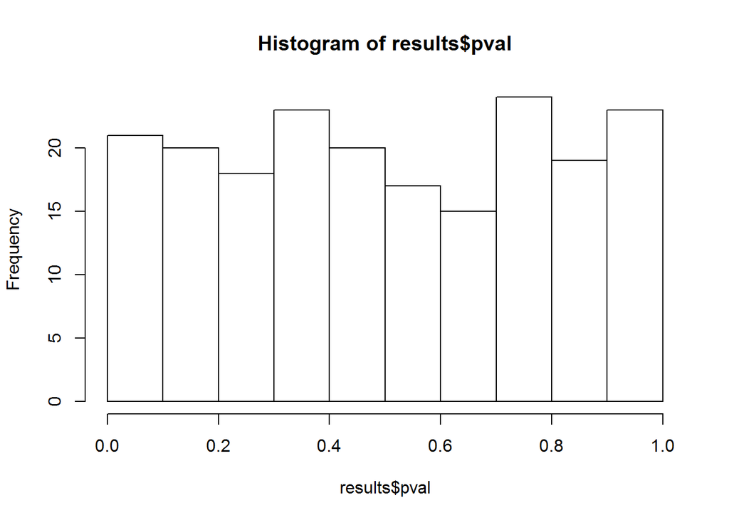

```r
hist(results$pval)
```

```r
sort(results$pvalbad)[1:20]
```

```
##  [1] 3.202004e-13 5.746218e-10 1.892824e-09 7.041205e-08 2.051453e-07
##  [6] 3.361812e-07 8.570226e-07 9.437271e-07 1.450475e-06 1.921281e-06
## [11] 3.061182e-06 4.152694e-06 5.046044e-06 3.276738e-05 3.294205e-05
## [16] 2.063664e-04 2.812807e-04 3.210468e-04 3.793380e-04 4.230282e-04
```

```r
# We got too many very small P values from the "bad" analysis!
sort(results$pval)[1:20]
```

```
##  [1] 0.001602504 0.001650021 0.002474437 0.002747240 0.008581656
##  [6] 0.009087584 0.010066944 0.022435157 0.030847694 0.030963006
## [11] 0.030977389 0.031348989 0.035505096 0.037237209 0.058388232
## [16] 0.062167090 0.066112278 0.066440878 0.078123799 0.081421718
```

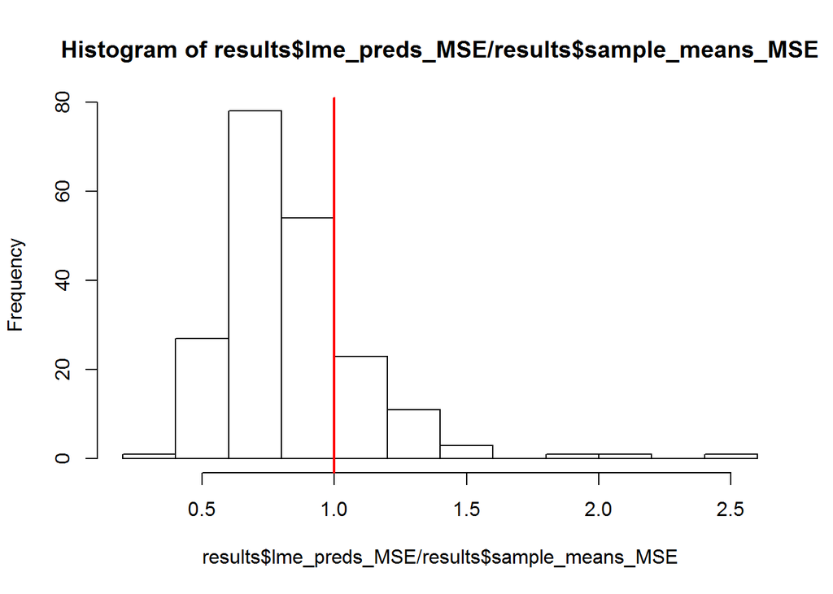

```r
hist(results$lme_preds_MSE/results$sample_means_MSE)
abline(v=1, col=2, lwd=2)
```

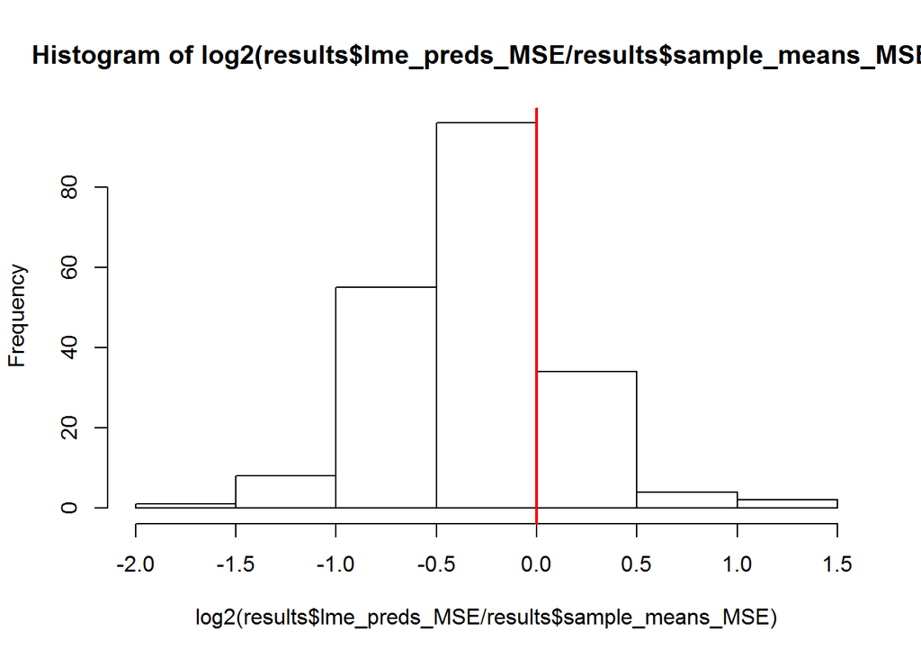

```r
hist(log2(results$lme_preds_MSE/results$sample_means_MSE))
abline(v=0, col=2, lwd=2)
```

So our mixed effects model gives us estimated true blood pressures that tend to be better than the simple average bp measurement for each person.

# Science survey data

## Look at the data and clean it a bit

School Science Survey Data on attitudes to science, from a survey containing results for students from classes in private schools and in public schools. From DAAG package.

- PrivPub: a factor with levels private school, public school
- school: a factor, coded to identify the school
- class: a factor, coded to identify the class
- sex: a factor with levels f, m
- like: a summary score based on two of the questions, on a scale from 1 (dislike) to 12 (like)
- Class: a factor with levels corresponding to each class

Get the data:

```r
science <- read.csv("http://www.stat.yale.edu/~jtc5/STAT230/data/science_DAAG.csv")
str(science)
```

```
## 'data.frame':    1385 obs. of  6 variables:
##  $ PrivPub: Factor w/ 2 levels "private","public": 2 2 2 2 2 2 2 2 2 2 ...
##  $ school : int  1 1 1 1 1 1 1 1 1 1 ...
##  $ class  : int  1 1 1 1 1 1 1 1 1 1 ...
##  $ sex    : Factor w/ 2 levels "f","m": 1 1 1 1 1 1 1 1 2 2 ...
##  $ like   : int  8 6 5 2 5 6 3 7 6 3 ...
##  $ Class  : num  1.1 1.1 1.1 1.1 1.1 1.1 1.1 1.1 1.1 1.1 ...
```

```r
for(j in c(2,3,6)){
  science[,j] <- as.factor(science[,j])
}
str(science)
```

```
## 'data.frame':    1385 obs. of  6 variables:
##  $ PrivPub: Factor w/ 2 levels "private","public": 2 2 2 2 2 2 2 2 2 2 ...
##  $ school : Factor w/ 41 levels "1","2","3","4",..: 1 1 1 1 1 1 1 1 1 1 ...
##  $ class  : Factor w/ 4 levels "1","2","3","4": 1 1 1 1 1 1 1 1 1 1 ...
##  $ sex    : Factor w/ 2 levels "f","m": 1 1 1 1 1 1 1 1 2 2 ...
##  $ like   : int  8 6 5 2 5 6 3 7 6 3 ...
##  $ Class  : Factor w/ 66 levels "1.1","1.2","1.3",..: 1 1 1 1 1 1 1 1 1 1 ...
```

```r
sum(is.na(science))
```

```
## [1] 2
```

```r
s <- na.omit(science)
names(s)[1] <- "pp"
```

How many public and private schools?

```r
table(s$school, s$pp)
```

```
##
##      private public
##   1        0     41
##   2        0     26
##   3        0     49
##   4        0     27
##   5        0     13
##   6        0     43
##   7        0     17
##   8        0     27
##   9        0     25
##   10       0     14
##   11       0     16
##   12       0     25
##   13       0     43
```

[output cut: 28 more lines]

```r
table(s$school, s$pp) > 0
```

```
##
##      private public
##   1    FALSE   TRUE
##   2    FALSE   TRUE
##   3    FALSE   TRUE
##   4    FALSE   TRUE
##   5    FALSE   TRUE
##   6    FALSE   TRUE
##   7    FALSE   TRUE
##   8    FALSE   TRUE
##   9    FALSE   TRUE
##   10   FALSE   TRUE
##   11   FALSE   TRUE
##   12   FALSE   TRUE
##   13   FALSE   TRUE
```

[output cut: 28 more lines]

```r
colSums(table(s$school, s$pp) > 0)
```

```
## private  public
##      12      29
```

```r
dim(s)
```

```
## [1] 1383    6
```

```r
names(s)[1] <- "pp"
names(s)
```

```
## [1] "pp"     "school" "class"  "sex"    "like"   "Class"
```

## Running a linear-mixed effects model

```r
m1 <- lme(like ~ sex + pp, random = ~1|school/class, data=s)
summary(m1)
```

```
## Linear mixed-effects model fit by REML
##  Data: s
##        AIC      BIC    logLik
##   5558.548 5589.927 -2773.274
##
## Random effects:
##  Formula: ~1 | school
##          (Intercept)
## StdDev: 0.0003092856
##
##  Formula: ~1 | class %in% school
##         (Intercept) Residual
## StdDev:   0.5662469  1.74704
##
## Fixed effects: like ~ sex + pp
##                Value  Std.Error   DF   t-value p-value
## (Intercept) 4.721780 0.16241921 1316 29.071559  0.0000
## sexm        0.182332 0.09819764 1316  1.856788  0.0636
## pppublic    0.411741 0.18572187   39  2.216976  0.0325
##  Correlation:
##          (Intr) sexm
## sexm     -0.309
## pppublic -0.795  0.012
##
## Standardized Within-Group Residuals:
##        Min         Q1        Med         Q3        Max
## -2.6926648 -0.6890973  0.1543503  0.6792248  2.5584077
##
## Number of Observations: 1383
## Number of Groups:
##            school class %in% school
##                41                66
```

To start by looking at the fixed effects (sex and pp) there is an estimated positive coefficient for public (suggesting a students in a public schools tend to have a more positive attitude toward science). There is also a positive coefficient for male. Both P values are around the traditional magnitude for statistical significance (.03, .06, .05, whatever) but of course would not be considered overwhelming.

Next we’ll look at the estimated variances of the random effects.

```r
v <- VarCorr(m1)
v[,"Variance"]
```

```
##       school =    (Intercept)        class =    (Intercept)       Residual
## "pdLogChol(1)" "9.565758e-08" "pdLogChol(1)" "3.206355e-01" "3.052149e+00"
```

```r
is.numeric(v)
```

```
## [1] FALSE
```

```r
dim(v)
```

```
## [1] 5 2
```

```r
0.5662469^2 # 0.3206
```

```
## [1] 0.3206356
```

```r
1.74704^2   # 3.052
```

```
## [1] 3.052149
```

Interpretation:  
class variance component is .3206  
residual (student) component is 3.052.

Note although .3206 looks small relative to 3.052, it is not unimportant. In fact, if we are thinking about the mean of a class of size n, the variance due to the residual component is 3.052/n, which will be smaller than the between class component of .32 if n > 9, which it is for 94% of the classes!

```r
mean(table(s$Class) > 9)
```

```
## [1] 0.9393939
```

## Some inappropriate analyses for comparison

This is the same kind of inappropriate analysis that we did with the blood pressures above.

```r
lmbad <- lm(like ~ sex + pp, data=s)
summary(lmbad)
```

```
##
## Call:
## lm(formula = like ~ sex + pp, data = s)
##
## Residuals:
##     Min      1Q  Median      3Q     Max
## -4.2862 -1.1353  0.2598  1.1088  3.2598
##
## Coefficients:
##             Estimate Std. Error t value Pr(>|t|)
## (Intercept)  4.74024    0.09955  47.616  < 2e-16 ***
## sexm         0.15093    0.09860   1.531 0.126064
## pppublic     0.39507    0.10511   3.759 0.000178 ***
## ---
## Signif. codes:  0 '***' 0.001 '**' 0.01 '*' 0.05 '.' 0.1 ' ' 1
##
## Residual standard error: 1.833 on 1380 degrees of freedom
## Multiple R-squared:  0.01175,    Adjusted R-squared:  0.01032
## F-statistic: 8.203 on 2 and 1380 DF,  p-value: 0.0002873
```

```r
# P value for pppublic is way too small.

lmbad2 <- lm(like ~ Class + sex + pp, data=s)
summary(lmbad2)
```

```
##
## Call:
## lm(formula = like ~ Class + sex + pp, data = s)
##
## Residuals:
##     Min      1Q  Median      3Q     Max
## -4.8511 -1.2097  0.2043  1.2749  5.1579
##
## Coefficients: (1 not defined because of singularities)
##             Estimate Std. Error t value Pr(>|t|)
## (Intercept)  5.34561    0.46859  11.408  < 2e-16 ***
## Class1.2    -0.51188    0.67248  -0.761  0.44669
## Class1.3    -0.81337    0.66005  -1.232  0.21807
## Class2.1     0.31194    0.57896   0.539  0.59012
## Class3.1    -0.54992    0.57503  -0.956  0.33908
## Class3.2     0.01215    0.59694   0.020  0.98377
## Class4.1     1.06537    0.57515   1.852  0.06420 .
## Class5.1    -1.31336    0.67276  -1.952  0.05113 .
## Class6.1    -0.10859    0.59189  -0.183  0.85446
## Class6.2     0.64632    0.60853   1.062  0.28839
## Class7.1    -0.16536    0.63032  -0.262  0.79310
## Class8.1    -0.03022    0.57550  -0.053  0.95814
## Class9.1    -0.05401    0.58296  -0.093  0.92619
## Class10.1    0.78571    0.65990   1.191  0.23400
## Class11.1    0.50720    0.63894   0.794  0.42745
## Class12.1    0.12147    0.58283   0.208  0.83493
## Class13.1    0.94966    0.57878   1.641  0.10108
## Class13.2    0.11548    0.63016   0.183  0.85463
## Class14.1   -0.96660    0.58748  -1.645  0.10014
## Class15.1   -1.44240    0.62220  -2.318  0.02059 *
## Class15.2   -0.56627    0.58288  -0.972  0.33148
## Class16.1   -1.80127    0.58715  -3.068  0.00220 **
## Class16.2    0.04147    0.58283   0.071  0.94328
## Class16.3   -0.30208    0.60852  -0.496  0.61969
## Class16.4   -0.83078    0.58281  -1.425  0.15425
## Class17.1   -0.38627    0.52800  -0.732  0.46456
## Class18.1    0.19048    0.60240   0.316  0.75191
## Class18.2   -0.29186    0.68702  -0.425  0.67103
## Class19.1   -0.87297    0.59185  -1.475  0.14046
## Class20.1    0.11840    0.67248   0.176  0.86027
```

[output cut: 29 more lines]

```
## Class36.4    0.18126    0.60242   0.301  0.76355
## Class37.1   -3.34561    1.11161  -3.010  0.00266 **
## Class38.1   -1.25653    0.60248  -2.086  0.03721 *
## Class39.1   -0.13594    0.57150  -0.238  0.81202
## Class40.1    0.01280    0.74594   0.017  0.98631
## Class41.1   -0.42304    0.64881  -0.652  0.51450
## Class41.2   -1.17530    0.58285  -2.016  0.04395 *
## sexm         0.19357    0.10029   1.930  0.05381 .
## pppublic          NA         NA      NA       NA
## ---
## Signif. codes:  0 '***' 0.001 '**' 0.01 '*' 0.05 '.' 0.1 ' ' 1
##
## Residual standard error: 1.746 on 1316 degrees of freedom
## Multiple R-squared:  0.1454, Adjusted R-squared:  0.1025
## F-statistic: 3.391 on 66 and 1316 DF,  p-value: < 2.2e-16
```

```r
summary(lm(like ~ Class + pp + sex, data=s))
```

```
##
## Call:
## lm(formula = like ~ Class + pp + sex, data = s)
##
## Residuals:
##     Min      1Q  Median      3Q     Max
## -4.8511 -1.2097  0.2043  1.2749  5.1579
##
## Coefficients: (1 not defined because of singularities)
##             Estimate Std. Error t value Pr(>|t|)
## (Intercept)  5.34561    0.46859  11.408  < 2e-16 ***
## Class1.2    -0.51188    0.67248  -0.761  0.44669
## Class1.3    -0.81337    0.66005  -1.232  0.21807
## Class2.1     0.31194    0.57896   0.539  0.59012
## Class3.1    -0.54992    0.57503  -0.956  0.33908
## Class3.2     0.01215    0.59694   0.020  0.98377
## Class4.1     1.06537    0.57515   1.852  0.06420 .
## Class5.1    -1.31336    0.67276  -1.952  0.05113 .
## Class6.1    -0.10859    0.59189  -0.183  0.85446
## Class6.2     0.64632    0.60853   1.062  0.28839
## Class7.1    -0.16536    0.63032  -0.262  0.79310
## Class8.1    -0.03022    0.57550  -0.053  0.95814
## Class9.1    -0.05401    0.58296  -0.093  0.92619
## Class10.1    0.78571    0.65990   1.191  0.23400
## Class11.1    0.50720    0.63894   0.794  0.42745
## Class12.1    0.12147    0.58283   0.208  0.83493
## Class13.1    0.94966    0.57878   1.641  0.10108
## Class13.2    0.11548    0.63016   0.183  0.85463
## Class14.1   -0.96660    0.58748  -1.645  0.10014
## Class15.1   -1.44240    0.62220  -2.318  0.02059 *
## Class15.2   -0.56627    0.58288  -0.972  0.33148
## Class16.1   -1.80127    0.58715  -3.068  0.00220 **
## Class16.2    0.04147    0.58283   0.071  0.94328
## Class16.3   -0.30208    0.60852  -0.496  0.61969
## Class16.4   -0.83078    0.58281  -1.425  0.15425
## Class17.1   -0.38627    0.52800  -0.732  0.46456
## Class18.1    0.19048    0.60240   0.316  0.75191
## Class18.2   -0.29186    0.68702  -0.425  0.67103
## Class19.1   -0.87297    0.59185  -1.475  0.14046
## Class20.1    0.11840    0.67248   0.176  0.86027
```

[output cut: 29 more lines]

```
## Class36.4    0.18126    0.60242   0.301  0.76355
## Class37.1   -3.34561    1.11161  -3.010  0.00266 **
## Class38.1   -1.25653    0.60248  -2.086  0.03721 *
## Class39.1   -0.13594    0.57150  -0.238  0.81202
## Class40.1    0.01280    0.74594   0.017  0.98631
## Class41.1   -0.42304    0.64881  -0.652  0.51450
## Class41.2   -1.17530    0.58285  -2.016  0.04395 *
## pppublic          NA         NA      NA       NA
## sexm         0.19357    0.10029   1.930  0.05381 .
## ---
## Signif. codes:  0 '***' 0.001 '**' 0.01 '*' 0.05 '.' 0.1 ' ' 1
##
## Residual standard error: 1.746 on 1316 degrees of freedom
## Multiple R-squared:  0.1454, Adjusted R-squared:  0.1025
## F-statistic: 3.391 on 66 and 1316 DF,  p-value: < 2.2e-16
```